# Comcast Telecom Complaints Project

# Text Visualization

Here i try to implement Word cloud just like what I did in python to explore the words in complaints and see which words have more frequency in complaints.

## Word Cloud

This word cloud represent the most used words in customer complaints so have Comcast which is the company name,Services ,Internet,billing and data which probably is concern with the issues of the complaint.

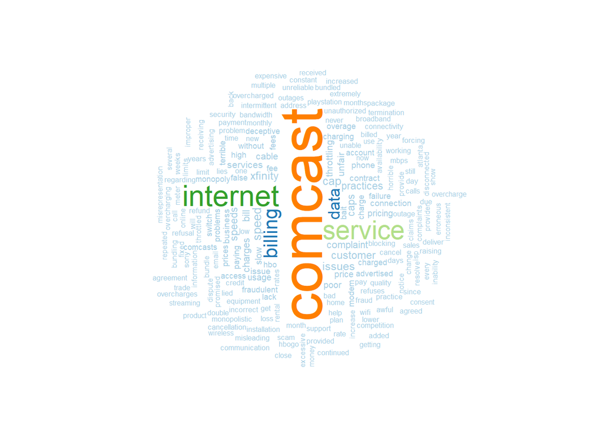

## Word Frequencies

This chart show how frequently of the top 10 words used in the customer complaint.

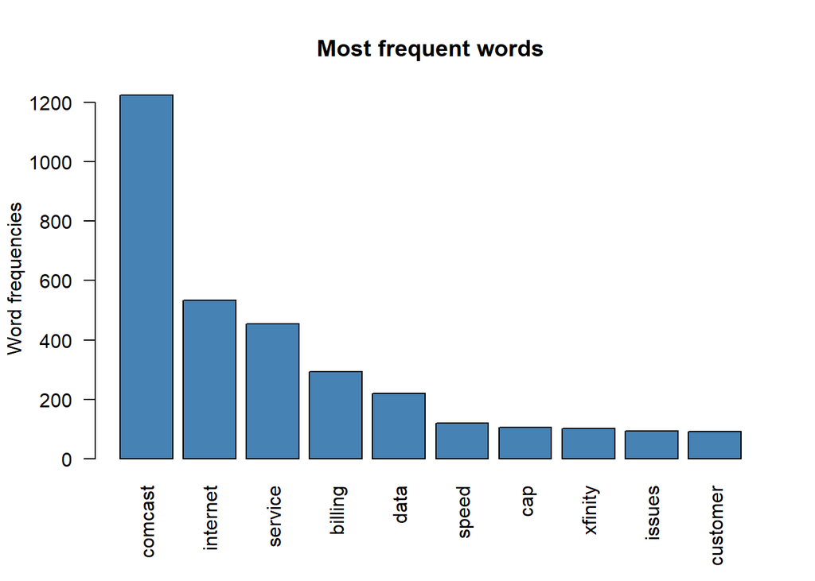

# NLP - Clustering

The idea is to use clustering is to extract the most used words in complaints and try to have a column containing the types for each complaint for example if a complaint is a slow internet then it will have the complaint type as the internet. This can help the Comcast company classify complaints into different types and solve the problems in-depth and not only for this one complaint like if on a certain day all complaints about internet then there may be a problem with the company service.

So the clustering should do: In the matrix `m`, which is a one-hot encoded matrix where each column corresponds to an entry of a complaint in the `telecome` data set, find the word that is most common, other than “comcast”.

Alternatively, in the matrix `m`, cluster each row, according to their one-hot profile.

This the first clustering I did it has 10 clusters and removed the word not related to customer complaint like company name , word service and billing.

Note : this can be enhanced in the future.

```
##
##    1    2    3    4    5    6    7    8    9   10
##  295   46 1021   29   50   67  441  208   23   44
```

This works if we transpose the dats set, so that each row corresponds to a complaint. Add cluster information to the original data

The results here represent the baseline accuracy of the model for each cluster.

```
##
##          1          2          3          4          5          6          7
## 0.13264388 0.02068345 0.45908273 0.01303957 0.02248201 0.03012590 0.19829137
##          8          9         10
## 0.09352518 0.01034173 0.01978417
```

Also, can we visualize the relationships in the future to repsent it better.